# Raport: Analiza struktury sektora bankowego w Polsce w latach 2009–2025

Autor: Jakub Sikorski 354584

## Wstęp i metodologia

Poniższe sprawozdanie przedstawia analizę zmian strukturalnych w polskim sektorze bankowym na przestrzeni ostatnich kilkunastu lat. Opracowanie zostało przygotowane na podstawie oficjalnych raportów statystycznych udostępnianych przez Komisję Nadzoru Finansowego (KNF).

Zgodnie z wymogami, dane zostały zaprezentowane w ujęciu rocznym. Aby zachować rzetelność i spójność pomiarów, z miesięcznych raportów wyodrębniono wyłącznie stany na koniec każdego okresu rozliczeniowego (grudzień każdego roku). Z tego względu z zestawienia wykluczono również niepełny rok 2026.

Celem analizy jest zbadanie długoterminowych trendów dotyczących liczby podmiotów na rynku, gęstości fizycznej sieci placówek oraz poziomu zatrudnienia w sektorze. Obserwowane w tym okresie zmiany są silnie powiązane z procesami transformacji cyfrowej, konsolidacji rynku (fuzje i przejęcia) oraz globalnej optymalizacji kosztowej prowadzonej przez instytucje finansowe.

```python
import pandas as pd
import matplotlib.pyplot as plt

dane_2017 = pd.read_csv('dane2017.csv', encoding='windows-1250',sep=';')
dane_2025 = pd.read_csv('dane2025.csv', encoding='windows-1250',sep=';')
```

```python
cols_2017 = {
    'Unnamed: 0': 'Data',
    'Liczba krajowych banków komercyjnych': 'Banki_komercyjne',
    'Liczba banków spółdzielczych': 'Banki_spoldzielcze',
    'Liczba oddziałów instytucji kredytowych': 'Oddzialy_instytucji_kredytowych',
    '   W kraju': 'Oddzialy_kraj',
    '   Za granicą': 'Oddzialy_zagranica',
    'Liczba zatrudnionych': 'Zatrudnienie'}

df_1 = dane_2017[list(cols_2017.keys())].rename(columns=cols_2017).copy()
```

```python
cols_2025 = {
    'Unnamed: 0': 'Data',
    '      Banki komercyjne': 'Banki_komercyjne',
    '      Banki spółdzielcze': 'Banki_spoldzielcze',
    '      Oddziały': 'Oddzialy_instytucji_kredytowych',
    '      W kraju': 'Oddzialy_kraj',
    '      Za granicą': 'Oddzialy_zagranica',
    '   Liczba zatrudnionych': 'Zatrudnienie'
}
df_2 = dane_2025[list(cols_2025.keys())].rename(columns=cols_2025).copy()
```

```python
dane_2017 = None
dane_2025 = None

df_1['Data'] = pd.to_datetime(df_1['Data'], format = '%d.%m.%Y', dayfirst = True)
df_2['Data'] = pd.to_datetime(df_2['Data'], format = '%Y-%m', dayfirst = True)


df = pd.concat([df_1,df_2], ignore_index = True)

df_1 = None
df_2 = None

def wyczysc_liczby(df):
    for kolumna in df.columns:
        if kolumna != 'Data':
            df[kolumna] = df[kolumna].astype(str).str.replace(' ', '').astype(float)
    return df

df = wyczysc_liczby(df)

df_roczne = df[df['Data'].dt.month == 12].copy()
df_roczne['Rok'] = df_roczne['Data'].dt.year
df_roczne = df_roczne.drop(columns=['Data'])
df_roczne = df_roczne.sort_values('Rok').reset_index(drop=True)
```

### Obserwacja trendu:

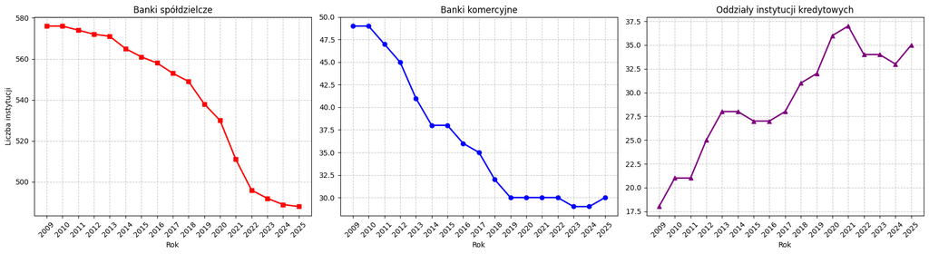

```python
fig, axes = plt.subplots(1, 3, figsize=(18, 5))

# WYKRES 1: Banki spółdzielcze
axes[0].plot(df_roczne['Rok'], df_roczne['Banki_spoldzielcze'], marker='s', color='red', linewidth=2)
axes[0].set_title('Banki spółdzielcze', fontsize=12)
axes[0].set_xlabel('Rok')
axes[0].set_ylabel('Liczba instytucji')
axes[0].set_xticks(df_roczne['Rok'])
axes[0].tick_params(axis='x', rotation=45)
axes[0].grid(True, linestyle='--', alpha=0.7)

# WYKRES 2: Banki komercyjne
axes[1].plot(df_roczne['Rok'], df_roczne['Banki_komercyjne'], marker='o', color='blue', linewidth=2)
axes[1].set_title('Banki komercyjne', fontsize=12)
axes[1].set_xlabel('Rok')
axes[1].set_xticks(df_roczne['Rok'])
axes[1].tick_params(axis='x', rotation=45)
axes[1].grid(True, linestyle='--', alpha=0.7)

# WYKRES 3: Oddziały instytucji kredytowych
axes[2].plot(df_roczne['Rok'], df_roczne['Oddzialy_instytucji_kredytowych'], marker='^', color='purple', linewidth=2)
axes[2].set_title('Oddziały instytucji kredytowych', fontsize=12)
axes[2].set_xlabel('Rok')
axes[2].set_xticks(df_roczne['Rok'])
axes[2].tick_params(axis='x', rotation=45)
axes[2].grid(True, linestyle='--', alpha=0.7)

plt.tight_layout()
plt.show()
```

### Interpretacja trendu: Zmiany w liczbie podmiotów rynkowych

Analiza wykresów ujawnia wyraźne, długoterminowe zmiany w strukturze polskiego sektora bankowego:

**Procentowy rozkład:**

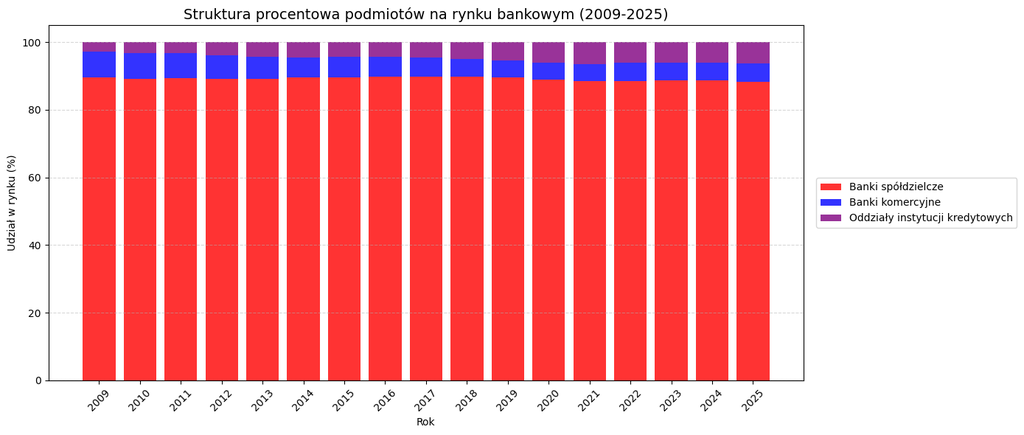

```python
suma_podmiotow = df_roczne['Banki_komercyjne'] + df_roczne['Banki_spoldzielcze'] + df_roczne['Oddzialy_instytucji_kredytowych']

proc_spoldzielcze = (df_roczne['Banki_spoldzielcze'] / suma_podmiotow) * 100
proc_komercyjne = (df_roczne['Banki_komercyjne'] / suma_podmiotow) * 100
proc_oddzialy = (df_roczne['Oddzialy_instytucji_kredytowych'] / suma_podmiotow) * 100

plt.figure(figsize=(14, 6))

p1 = plt.bar(df_roczne['Rok'], proc_spoldzielcze, label='Banki spółdzielcze', color='red', alpha=0.8)
p2 = plt.bar(df_roczne['Rok'], proc_komercyjne, bottom=proc_spoldzielcze, label='Banki komercyjne', color='blue', alpha=0.8)
p3 = plt.bar(df_roczne['Rok'], proc_oddzialy, bottom=proc_spoldzielcze + proc_komercyjne, label='Oddziały instytucji kredytowych', color='purple', alpha=0.8)

plt.title('Struktura procentowa podmiotów na rynku bankowym (2009-2025)', fontsize=14)
plt.xlabel('Rok')
plt.ylabel('Udział w rynku (%)')
plt.xticks(df_roczne['Rok'], rotation=45)

plt.legend(bbox_to_anchor=(1.01, 0.5), loc='center left')
plt.grid(axis='y', linestyle='--', alpha=0.5)

plt.tight_layout()
plt.show()
```

### Procentowy rozkład: Struktura podmiotowa rynku

- **Dominacja banków spółdzielczych:** Wykres skumulowany jednoznacznie dowodzi, że pomimo spadku liczby bezwzględnej podmiotów, banki spółdzielcze niezmiennie stanowią **około 90% wszystkich instytucji** na polskim rynku. Co ciekawe, ten proporcjonalny udział utrzymuje się na niemal identycznym poziomie przez cały badany okres (2009-2025).
- **Specyfika sektora:** Tak ogromny udział procentowy nie wynika z ich siły kapitałowej, lecz z ogromnego **rozdrobnienia tego sektora**. Opiera się on na setkach małych, lokalnych jednostek, które skupiają się na obsłudze mniejszych społeczności, rolnictwa i lokalnego biznesu, podczas gdy banków komercyjnych jest zaledwie kilkadziesiąt, ale obsługują one większość kapitału na rynku.

**Interpretacja trendu:**

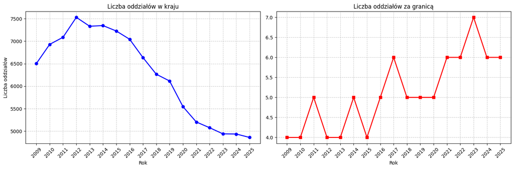

```python
fig, axes = plt.subplots(1, 2, figsize=(15, 5))

# WYKRES 1: Oddziały w kraju
axes[0].plot(df_roczne['Rok'], df_roczne['Oddzialy_kraj'], marker='o', color='blue', linewidth=2)
axes[0].set_title('Liczba oddziałów w kraju', fontsize=12)
axes[0].set_xlabel('Rok')
axes[0].set_ylabel('Liczba oddziałów')
axes[0].set_xticks(df_roczne['Rok'])
axes[0].tick_params(axis='x', rotation=45)
axes[0].grid(True, linestyle='--', alpha=0.7)

# WYKRES 2: Oddziały za granicą
axes[1].plot(df_roczne['Rok'], df_roczne['Oddzialy_zagranica'], marker='s', color='red', linewidth=2)
axes[1].set_title('Liczba oddziałów za granicą', fontsize=12)
axes[1].set_xlabel('Rok')
axes[1].set_xticks(df_roczne['Rok'])
axes[1].tick_params(axis='x', rotation=45)
axes[1].grid(True, linestyle='--', alpha=0.7)

plt.tight_layout()
plt.show()
```

**Interpretacja udzialu oddzialow w calkowitej strukturze:**

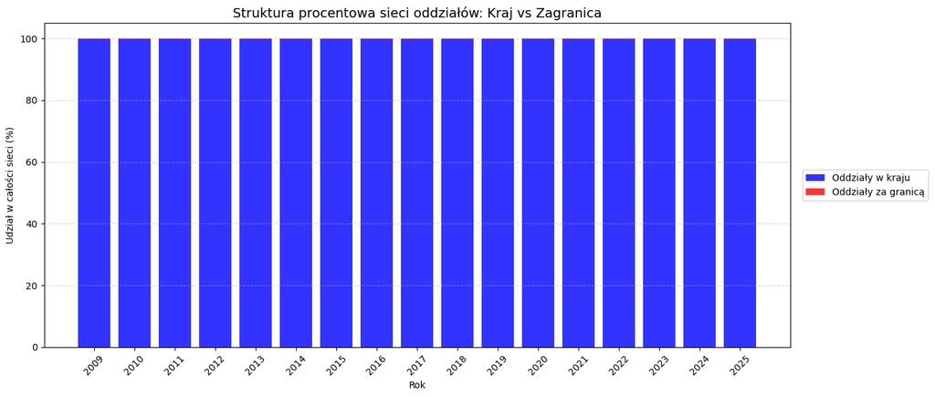

```python
suma_oddzialow = df_roczne['Oddzialy_kraj'] + df_roczne['Oddzialy_zagranica']

proc_kraj = (df_roczne['Oddzialy_kraj'] / suma_oddzialow) * 100
proc_zagranica = (df_roczne['Oddzialy_zagranica'] / suma_oddzialow) * 100

plt.figure(figsize=(14, 6))

plt.bar(df_roczne['Rok'], proc_kraj, label='Oddziały w kraju', color='blue', alpha=0.8)
plt.bar(df_roczne['Rok'], proc_zagranica, bottom=proc_kraj, label='Oddziały za granicą', color='red', alpha=0.8)

plt.title('Struktura procentowa sieci oddziałów: Kraj vs Zagranica', fontsize=14)
plt.xlabel('Rok')
plt.ylabel('Udział w całości sieci (%)')
plt.xticks(df_roczne['Rok'], rotation=45)

plt.legend(bbox_to_anchor=(1.01, 0.5), loc='center left')
plt.grid(axis='y', linestyle='--', alpha=0.5)

plt.tight_layout()
plt.show()
```

### Interpretacja udziału oddziałów w całkowitej strukturze sieci

Wykres kolumnowy dobitnie uwydatnia lokalny charakter polskiego sektora bankowego. Mimo dynamicznych zmian rynkowych i zamykania tysięcy placówek w Polsce, **oddziały krajowe nieprzerwanie stanowią ponad 99% całej infrastruktury fizycznej**. Udział placówek zagranicznych jest na tyle bliski zeru, że pozostaje niemal niewidoczny na wykresie. Udowadnia to całkowity brak strategii budowania fizycznej sieci detalicznej polskich banków poza granicami RP.

**Interpretacja trendu:**

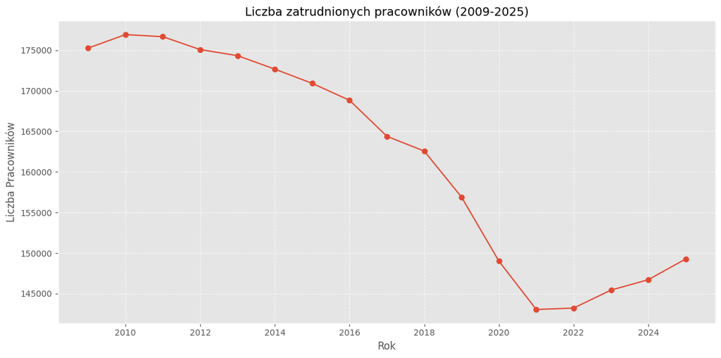

```python
plt.style.use('ggplot')

plt.figure(figsize=(12, 6))
plt.plot(df_roczne['Rok'], df_roczne['Zatrudnienie'], marker='o')
plt.title('Liczba zatrudnionych pracowników (2009-2025)', fontsize=14)
plt.xlabel('Rok')
plt.ylabel('Liczba Pracowników')
plt.grid(True, linestyle='--', alpha=0.7)
plt.tight_layout()
plt.show()
```

### Interpretacja trendu: Dynamika zatrudnienia w sektorze bankowym

- **Spadek zatrudnienia (do 2021 roku):** Krzywa zatrudnienia silnie koreluje z procesem likwidacji oddziałów fizycznych. Automatyzacja procesów bankowych, przeniesienie obsługi do kanałów zdalnych i cięcie kosztów operacyjnych doprowadziły do znacznej, wieloletniej redukcji etatów. Zwolnienia dotknęły głównie pracowników sieci sprzedaży, tzw. "front-office" (kasjerów, doradców klienta detalicznego).
- **Odbicie trendu (po 2021 roku):** Zauważalny wzrost liczby pracowników w ostatnich latach nie oznacza powrotu do otwierania placówek, lecz sygnalizuje **zmianę struktury kompetencyjnej** wewnątrz banków. Redukcja w oddziałach została zahamowana, a instytucje finansowe zaczęły masowo zatrudniać wysoko wykwalifikowanych specjalistów w centralach – ekspertów z branży IT, cyberbezpieczeństwa, analityków danych oraz deweloperów rozwiązań opartych na Sztucznej Inteligencji.